# Análisis de la población de Cali, Valle del Cauca, Bogotá, D.C y Medellín, Antioquia sobre los requerimientos promedio de energía diarios, información antropométrica y actividad física

Proyecto: Análisis sobre la asequibilidad de os hogares urbanos a dietas de costo mínimo para tres ciudades principales de Colombia durante el período 2019-2023

Daniela Valdés Cárdenas

17/03/2026

# 1 Objetivo

Este documento resume, para **Cali**, **Bogotá** y **Medellín**, la estructura poblacional por sexo y edad, la antropometría promedio, la actividad física predominante y los **requerimientos estimados de energía (EER)** calculados con las ecuaciones de la **NASEM 2023**.

El propósito es construir, para cada ciudad, una caracterización demográfica y antropométrica que permita aproximar los requerimientos diarios de energía de la población urbana, diferenciando por sexo y grupos etarios. Posteriormente, estos requerimientos se ponderan con la estructura poblacional observada en el **CNPV 2018**.

# 2 Rutas y parámetros

# 3 Funciones auxiliares

# 4 CNPV 2018: estructura poblacional

La estructura poblacional constituye el punto de partida para el cálculo de los requerimientos promedio de energía, pues permite identificar la composición por sexo y edad de la población residente en cada ciudad.

## 4.1 Cali

El Censo Nacional de Población y Vivienda 2018 permite identificar la distribución por sexo y grupos de edad de la población de **Cali**. Esta estructura es relevante porque sirve como ponderador demográfico en la estimación final de los requerimientos diarios promedio de energía.

Estructura poblacional de Cali (CNPV 2018)

| grupo | Masculino | Femenino | total |
| --- | --- | --- | --- |
| 0 a 4 | 50116 | 47843 | 97959 |
| 5 a 9 | 54971 | 52577 | 107548 |
| 10 a 14 | 59961 | 58078 | 118039 |
| 15 a 19 | 68413 | 68168 | 136581 |
| 20 a 24 | 78868 | 81403 | 160271 |
| 25 a 29 | 74571 | 79355 | 153926 |
| 30 a 34 | 67137 | 72551 | 139688 |
| 35 a 39 | 64134 | 72265 | 136399 |
| 40 a 44 | 54958 | 64828 | 119786 |
| 45 a 49 | 54018 | 65395 | 119413 |
| 50 a 54 | 54746 | 67333 | 122079 |
| 55 a 59 | 48150 | 61470 | 109620 |
| 60 a 64 | 38130 | 52267 | 90397 |
| 65 a 69 | 29229 | 40170 | 69399 |
| 70 a 74 | 21389 | 30234 | 51623 |
| 75 a 79 | 15234 | 23075 | 38309 |
| 80 a 84 | 10182 | 16832 | 27014 |
| 85 a 89 | 5604 | 10306 | 15910 |
| 90 a 94 | 2240 | 4273 | 6513 |
| 95 a 99 | 548 | 1215 | 1763 |
| 100 y más | 253 | 379 | 632 |

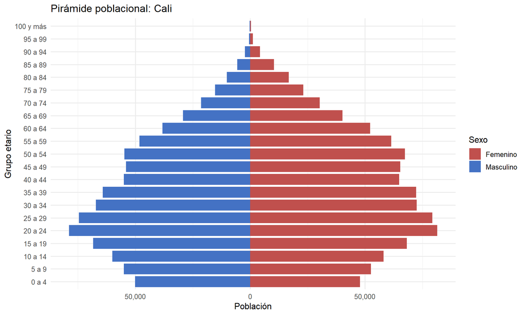

## 4.2 Bogotá

La información censal de **Bogotá** permite observar la composición etaria y por sexo de la ciudad. Esta composición se incorpora posteriormente al promedio ponderado de requerimientos energéticos.

Estructura poblacional de Bogotá (CNPV 2018)

| grupo | Masculino | Femenino | total |
| --- | --- | --- | --- |
| 0 a 4 | 211128 | 201017 | 412145 |
| 5 a 9 | 228123 | 219872 | 447995 |
| 10 a 14 | 241423 | 232387 | 473810 |
| 15 a 19 | 279911 | 275796 | 555707 |
| 20 a 24 | 346803 | 349905 | 696708 |
| 25 a 29 | 337916 | 341717 | 679633 |
| 30 a 34 | 301163 | 307390 | 608553 |
| 35 a 39 | 277944 | 296670 | 574614 |
| 40 a 44 | 224362 | 255432 | 479794 |
| 45 a 49 | 207297 | 245853 | 453150 |
| 50 a 54 | 203920 | 248675 | 452595 |
| 55 a 59 | 177520 | 222457 | 399977 |
| 60 a 64 | 135470 | 175006 | 310476 |
| 65 a 69 | 97586 | 129338 | 226924 |
| 70 a 74 | 66859 | 91784 | 158643 |
| 75 a 79 | 45668 | 66404 | 112072 |
| 80 a 84 | 28049 | 46044 | 74093 |
| 85 a 89 | 14921 | 26745 | 41666 |
| 90 a 94 | 5324 | 11193 | 16517 |
| 95 a 99 | 1347 | 3118 | 4465 |
| 100 y más | 852 | 1080 | 1932 |

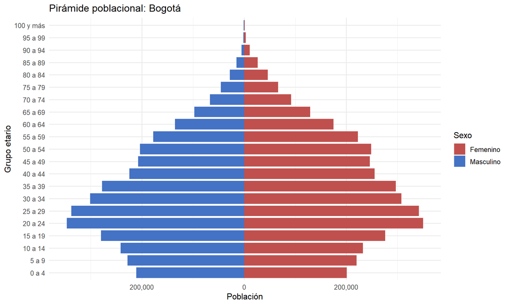

## 4.3 Medellín

Para **Medellín**, el CNPV 2018 también ofrece la base demográfica con la cual se organiza la población por grupos etarios y sexo, insumo fundamental para construir los promedios de energía por ciudad.

Estructura poblacional de Medellín (CNPV 2018)

| grupo | Masculino | Femenino | total |
| --- | --- | --- | --- |
| 0 a 4 | 62776 | 59633 | 122409 |
| 5 a 9 | 66361 | 63937 | 130298 |
| 10 a 14 | 77958 | 75538 | 153496 |
| 15 a 19 | 93254 | 90930 | 184184 |
| 20 a 24 | 113044 | 113729 | 226773 |
| 25 a 29 | 111446 | 111364 | 222810 |
| 30 a 34 | 96498 | 98388 | 194886 |
| 35 a 39 | 86544 | 94380 | 180924 |
| 40 a 44 | 66300 | 80111 | 146411 |
| 45 a 49 | 64248 | 81134 | 145382 |
| 50 a 54 | 68518 | 89015 | 157533 |
| 55 a 59 | 61138 | 81072 | 142210 |
| 60 a 64 | 47652 | 65823 | 113475 |
| 65 a 69 | 35894 | 50982 | 86876 |
| 70 a 74 | 25318 | 37007 | 62325 |
| 75 a 79 | 17359 | 26536 | 43895 |
| 80 a 84 | 10949 | 18546 | 29495 |
| 85 a 89 | 6390 | 11704 | 18094 |
| 90 a 94 | 2600 | 5193 | 7793 |
| 95 a 99 | 707 | 1511 | 2218 |
| 100 y más | 319 | 524 | 843 |

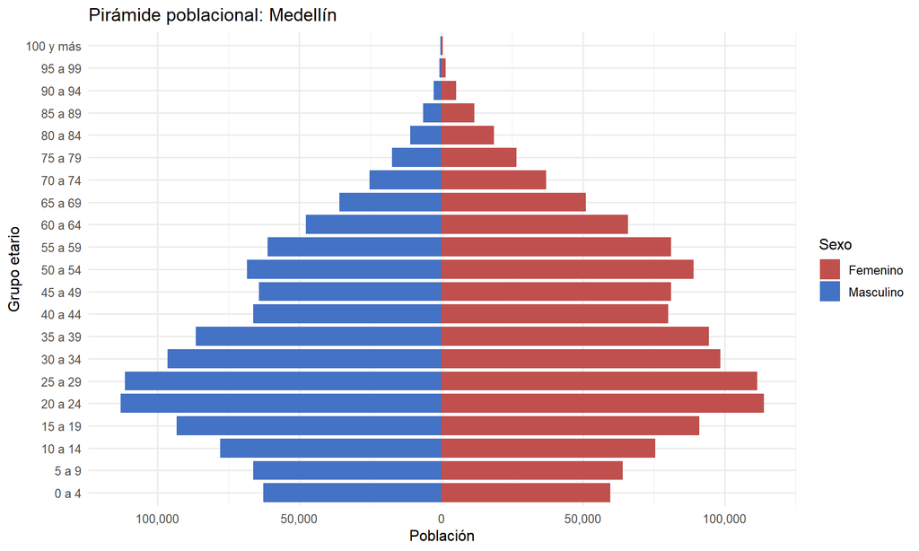

# 5 ENSIN 2015: antropometría

A continuación se presentan los promedios de **peso** y **talla** obtenidos a partir de la base de **antropometría de la ENSIN 2015**. El objetivo de esta sección es construir, para cada grupo etario y sexo, los insumos antropométricos necesarios para la estimación de los requerimientos de energía.

Antropometría promedio por sexo y grupo etario - división 1

| dominio_geo | sexo | grupo_edad | edad_rep | peso_prom | talla_prom | n |
| --- | --- | --- | --- | --- | --- | --- |
| Bogotá | Femenino | [14,18) | 15.25 | 51.59 | 156.32 | 270 |
| Bogotá | Femenino | [18,30) | 23.39 | 60.09 | 157.27 | 945 |
| Bogotá | Femenino | [30,60) | 43.47 | 65.72 | 155.35 | 1569 |
| Bogotá | Femenino | [60,Inf) | 61.90 | 65.37 | 151.88 | 177 |
| Bogotá | Masculino | [14,18) | 15.59 | 56.11 | 165.70 | 237 |
| Bogotá | Masculino | [18,30) | 23.44 | 67.53 | 169.37 | 733 |
| Bogotá | Masculino | [30,60) | 43.32 | 74.97 | 167.70 | 1168 |
| Bogotá | Masculino | [60,Inf) | 61.87 | 75.47 | 163.90 | 117 |
| Cali | Femenino | [14,18) | 15.71 | 56.38 | 158.01 | 103 |
| Cali | Femenino | [18,30) | 23.66 | 62.84 | 157.55 | 385 |
| Cali | Femenino | [30,60) | 43.67 | 68.15 | 156.23 | 730 |
| Cali | Femenino | [60,Inf) | 61.91 | 67.15 | 156.16 | 91 |
| Cali | Masculino | [14,18) | 15.62 | 58.12 | 167.85 | 87 |
| Cali | Masculino | [18,30) | 23.22 | 72.73 | 170.97 | 288 |
| Cali | Masculino | [30,60) | 42.67 | 76.77 | 168.71 | 486 |
| Cali | Masculino | [60,Inf) | 61.79 | 75.98 | 165.50 | 67 |
| Medellín | Femenino | [14,18) | 15.55 | 55.83 | 157.48 | 171 |
| Medellín | Femenino | [18,30) | 23.30 | 61.88 | 158.24 | 526 |
| Medellín | Femenino | [30,60) | 43.84 | 65.98 | 155.98 | 1059 |
| Medellín | Femenino | [60,Inf) | 62.16 | 66.19 | 153.74 | 119 |
| Medellín | Masculino | [14,18) | 15.62 | 58.02 | 166.15 | 141 |
| Medellín | Masculino | [18,30) | 23.50 | 71.88 | 170.36 | 442 |
| Medellín | Masculino | [30,60) | 43.29 | 74.87 | 168.07 | 662 |
| Medellín | Masculino | [60,Inf) | 62.08 | 72.91 | 165.65 | 69 |

Antropometría promedio por sexo y grupo etario - división 2

| dominio_geo | sexo | grupo_edad | edad_rep | peso_prom | talla_prom | n |
| --- | --- | --- | --- | --- | --- | --- |
| Bogotá | Femenino | [14,18) | 15.25 | 51.59 | 156.32 | 270 |
| Bogotá | Femenino | [18,31) | 23.84 | 60.27 | 157.22 | 1010 |
| Bogotá | Femenino | [31,51) | 40.08 | 65.95 | 155.76 | 1092 |
| Bogotá | Femenino | [51,70) | 56.92 | 65.43 | 153.38 | 589 |
| Bogotá | Masculino | [14,18) | 15.59 | 56.11 | 165.70 | 237 |
| Bogotá | Masculino | [18,31) | 23.87 | 67.87 | 169.41 | 787 |
| Bogotá | Masculino | [31,51) | 40.00 | 74.99 | 168.12 | 820 |
| Bogotá | Masculino | [51,70) | 56.71 | 75.30 | 165.49 | 411 |
| Cali | Femenino | [14,18) | 15.71 | 56.38 | 158.01 | 103 |
| Cali | Femenino | [18,31) | 24.22 | 63.06 | 157.58 | 415 |
| Cali | Femenino | [31,51) | 40.60 | 68.46 | 156.63 | 483 |
| Cali | Femenino | [51,70) | 57.09 | 67.59 | 155.22 | 308 |
| Cali | Masculino | [14,18) | 15.62 | 58.12 | 167.85 | 87 |
| Cali | Masculino | [18,31) | 23.61 | 72.89 | 170.96 | 304 |
| Cali | Masculino | [31,51) | 39.37 | 77.22 | 169.33 | 332 |
| Cali | Masculino | [51,70) | 56.77 | 75.70 | 166.20 | 205 |
| Medellín | Femenino | [14,18) | 15.55 | 55.83 | 157.48 | 171 |
| Medellín | Femenino | [18,31) | 23.88 | 62.07 | 158.00 | 565 |
| Medellín | Femenino | [31,51) | 40.03 | 65.64 | 156.64 | 705 |
| Medellín | Femenino | [51,70) | 56.92 | 66.82 | 154.30 | 434 |
| Medellín | Masculino | [14,18) | 15.62 | 58.02 | 166.15 | 141 |
| Medellín | Masculino | [18,31) | 23.97 | 71.89 | 170.20 | 473 |
| Medellín | Masculino | [31,51) | 39.85 | 76.02 | 169.26 | 446 |
| Medellín | Masculino | [51,70) | 56.86 | 72.55 | 165.17 | 254 |

# 6 Actividad física predominante

Siguiendo la lógica del documento base, la actividad física se clasifica aquí a partir de la información disponible en **ENSIN 2015**. Dado el tipo de variables disponibles, la aproximación utilizada distingue principalmente entre **actividad ligera** y **actividad moderada**, categorías que luego se traducen a los niveles de actividad requeridos por las ecuaciones de energía.

Actividad física predominante - división 1

| dominio_geo | sexo | grupo_edad | AF_predominante | freq |
| --- | --- | --- | --- | --- |
| Bogotá | Femenino | [14,18) | Ligera | 114879.99 |
| Bogotá | Femenino | [18,30) | Ligera | 183873.31 |
| Bogotá | Femenino | [30,60) | Ligera | 342610.78 |
| Bogotá | Femenino | [60,Inf) | Ligera | 25678.88 |
| Bogotá | Masculino | [14,18) | Ligera | 109032.59 |
| Bogotá | Masculino | [18,30) | Moderada | 290330.26 |
| Bogotá | Masculino | [30,60) | Moderada | 314538.16 |
| Bogotá | Masculino | [60,Inf) | Moderada | 24950.35 |
| Cali | Femenino | [14,18) | Ligera | 81241.55 |
| Cali | Femenino | [18,30) | Ligera | 87454.75 |
| Cali | Femenino | [30,60) | Ligera | 153691.43 |
| Cali | Femenino | [60,Inf) | Ligera | 26120.37 |
| Cali | Masculino | [14,18) | Ligera | 74648.09 |
| Cali | Masculino | [18,30) | Moderada | 150316.58 |
| Cali | Masculino | [30,60) | Moderada | 260029.88 |
| Cali | Masculino | [60,Inf) | Moderada | 31151.41 |
| Medellín | Femenino | [14,18) | Ligera | 105308.62 |
| Medellín | Femenino | [18,30) | Ligera | 179460.16 |
| Medellín | Femenino | [30,60) | Ligera | 480171.56 |
| Medellín | Femenino | [60,Inf) | Ligera | 60047.70 |
| Medellín | Masculino | [14,18) | Ligera | 86358.74 |
| Medellín | Masculino | [18,30) | Moderada | 230509.50 |
| Medellín | Masculino | [30,60) | Moderada | 321803.71 |
| Medellín | Masculino | [60,Inf) | Moderada | 38952.00 |

Actividad física predominante - división 2

| dominio_geo | sexo | grupo_edad | AF_predominante | freq |
| --- | --- | --- | --- | --- |
| Bogotá | Femenino | [14,18) | Ligera | 114879.99 |
| Bogotá | Femenino | [18,31) | Ligera | 191945.26 |
| Bogotá | Femenino | [31,51) | Ligera | 231788.18 |
| Bogotá | Femenino | [51,70) | Ligera | 128429.54 |
| Bogotá | Masculino | [14,18) | Ligera | 109032.59 |
| Bogotá | Masculino | [18,31) | Moderada | 309941.87 |
| Bogotá | Masculino | [31,51) | Moderada | 232358.42 |
| Bogotá | Masculino | [51,70) | Moderada | 87518.48 |
| Cali | Femenino | [14,18) | Ligera | 81241.55 |
| Cali | Femenino | [18,31) | Ligera | 92434.92 |
| Cali | Femenino | [31,51) | Ligera | 103795.07 |
| Cali | Femenino | [51,70) | Moderada | 71154.74 |
| Cali | Masculino | [14,18) | Ligera | 74648.09 |
| Cali | Masculino | [18,31) | Moderada | 157397.20 |
| Cali | Masculino | [31,51) | Moderada | 186937.78 |
| Cali | Masculino | [51,70) | Moderada | 97162.89 |
| Medellín | Femenino | [14,18) | Ligera | 105308.62 |
| Medellín | Femenino | [18,31) | Ligera | 202382.47 |
| Medellín | Femenino | [31,51) | Ligera | 296451.78 |
| Medellín | Femenino | [51,70) | Ligera | 220845.16 |
| Medellín | Masculino | [14,18) | Ligera | 86358.74 |
| Medellín | Masculino | [18,31) | Moderada | 252419.82 |
| Medellín | Masculino | [31,51) | Ligera | 175815.06 |
| Medellín | Masculino | [51,70) | Moderada | 169490.32 |

## 6.1 Ecuaciones NASEM 2023 utilizadas en el cálculo del EER

A continuación se explicitan las ecuaciones de **requerimiento estimado de energía (EER)** utilizadas en este documento. Estas corresponden a las ecuaciones actualizadas de la **National Academies of Sciences, Engineering, and Medicine (2023)** para adolescentes de **14 a 18.99 años** y para población adulta de **19 años o más**.

Ecuaciones NASEM 2023 utilizadas para el cálculo del EER

| grupo_edad_modelo | sexo | categoria_pal | ecuacion |
| --- | --- | --- | --- |
| 19+ años | M | Inactivo | EER = 753.07 - (10.83 × edad) + (6.50 × altura) + (14.10 × peso) |
| 19+ años | M | Baja actividad | EER = 581.47 - (10.83 × edad) + (8.30 × altura) + (14.94 × peso) |
| 19+ años | M | Activo | EER = 1004.82 - (10.83 × edad) + (6.52 × altura) + (15.91 × peso) |
| 19+ años | M | Muy activo | EER = -517.88 - (10.83 × edad) + (15.61 × altura) + (19.11 × peso) |
| 19+ años | F | Inactivo | EER = 584.90 - (7.01 × edad) + (5.72 × altura) + (11.71 × peso) |
| 19+ años | F | Baja actividad | EER = 575.77 - (7.01 × edad) + (6.60 × altura) + (12.14 × peso) |
| 19+ años | F | Activo | EER = 710.25 - (7.01 × edad) + (6.54 × altura) + (12.34 × peso) |
| 19+ años | F | Muy activo | EER = 511.83 - (7.01 × edad) + (9.07 × altura) + (12.56 × peso) |
| 14 a 18.99 años | M | Inactivo | EER = -447.51 + (3.68 × edad) + (13.01 × altura) + (13.15 × peso) + 20 |
| 14 a 18.99 años | M | Baja actividad | EER = 19.12 + (3.68 × edad) + (8.62 × altura) + (20.28 × peso) + 20 |
| 14 a 18.99 años | M | Activo | EER = -388.19 + (3.68 × edad) + (12.66 × altura) + (20.46 × peso) + 20 |
| 14 a 18.99 años | M | Muy activo | EER = -671.75 + (3.68 × edad) + (15.38 × altura) + (23.25 × peso) + 20 |
| 14 a 18.99 años | F | Inactivo | EER = 55.59 - (22.25 × edad) + (8.43 × altura) + (17.07 × peso) + 20 |
| 14 a 18.99 años | F | Baja actividad | EER = -297.54 - (22.25 × edad) + (12.77 × altura) + (14.73 × peso) + 20 |
| 14 a 18.99 años | F | Activo | EER = -189.55 - (22.25 × edad) + (11.74 × altura) + (18.34 × peso) + 20 |
| 14 a 18.99 años | F | Muy activo | EER = -709.59 - (22.25 × edad) + (18.22 × altura) + (14.25 × peso) + 20 |

En este documento, las ecuaciones anteriores se implementan directamente en la función `eer_iom_2023()`. Por tanto, los requerimientos energéticos calculados para **Cali**, **Bogotá** y **Medellín** sí se basan en las ecuaciones nuevas que compartiste.

## 6.2 Distribución de actividad física por ciudad, sexo y grupo etario

La siguiente gráfica muestra la composición relativa de la actividad física observada en cada ciudad, diferenciando por sexo y grupos etarios. Esto permite identificar en qué segmentos predomina una actividad ligera o moderada.

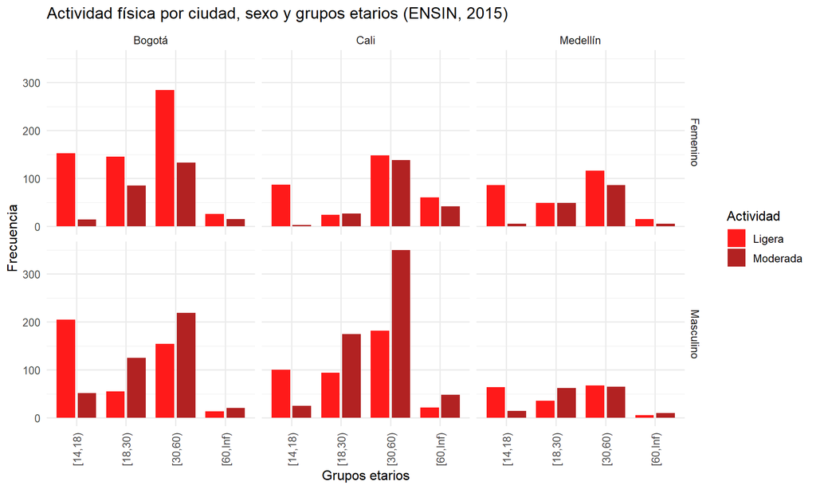

## 6.3 Actividad física predominante por ciudad, sexo y grupo etario

Esta visualización resume, por grupo etario, cuál es la categoría predominante de actividad física identificada en cada ciudad.

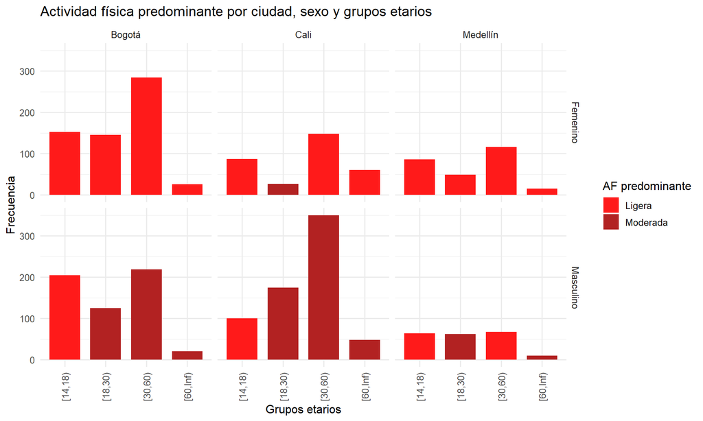

## 6.4 Comparación general de actividad física por ciudad

Finalmente, se presenta una comparación agregada entre ciudades, útil para una lectura más ejecutiva del perfil de actividad física.

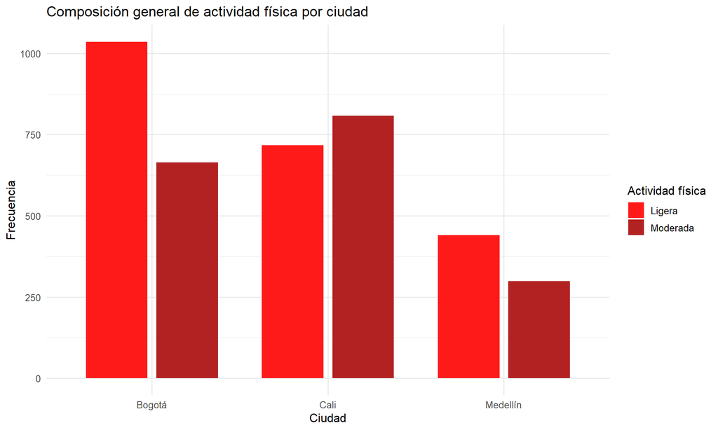

# 7 EER por sexo, edad y ciudad

Con base en la antropometría promedio y en la categoría de actividad física predominante, se calculan los **requerimientos estimados de energía (EER)** para cada ciudad, sexo y grupo etario.

## 7.1 Resultados detallados: división 1

EER calculado - división 1

| dominio_geo | sexo | grupo_edad | edad_rep | peso_prom | talla_prom | n | AF_predominante | freq | pal_iom | eer_kcal_dia |
| --- | --- | --- | --- | --- | --- | --- | --- | --- | --- | --- |
| Bogotá | Femenino | [14,18) | 15.25 | 51.59 | 156.32 | 270 | Ligera | 114879.99 | Low active | 2139.18 |
| Bogotá | Femenino | [18,30) | 23.39 | 60.09 | 157.27 | 945 | Ligera | 183873.31 | Low active | 2179.24 |
| Bogotá | Femenino | [30,60) | 43.47 | 65.72 | 155.35 | 1569 | Ligera | 342610.78 | Low active | 2094.14 |
| Bogotá | Femenino | [60,Inf) | 61.90 | 65.37 | 151.88 | 177 | Ligera | 25678.88 | Low active | 1937.80 |
| Bogotá | Masculino | [14,18) | 15.59 | 56.11 | 165.70 | 237 | Ligera | 109032.59 | Low active | 2662.64 |
| Bogotá | Masculino | [18,30) | 23.44 | 67.53 | 169.37 | 733 | Moderada | 290330.26 | Active | 2929.74 |
| Bogotá | Masculino | [30,60) | 43.32 | 74.97 | 167.70 | 1168 | Moderada | 314538.16 | Active | 2821.77 |
| Bogotá | Masculino | [60,Inf) | 61.87 | 75.47 | 163.90 | 117 | Moderada | 24950.35 | Active | 2604.24 |
| Cali | Femenino | [14,18) | 15.71 | 56.38 | 158.01 | 103 | Ligera | 81241.55 | Low active | 2221.31 |
| Cali | Femenino | [18,30) | 23.66 | 62.84 | 157.55 | 385 | Ligera | 87454.75 | Low active | 2212.67 |
| Cali | Femenino | [30,60) | 43.67 | 68.15 | 156.23 | 730 | Ligera | 153691.43 | Low active | 2128.00 |
| Cali | Femenino | [60,Inf) | 61.91 | 67.15 | 156.16 | 91 | Ligera | 26120.37 | Low active | 1987.65 |
| Cali | Masculino | [14,18) | 15.62 | 58.12 | 167.85 | 87 | Ligera | 74648.09 | Low active | 2722.17 |
| Cali | Masculino | [18,30) | 23.22 | 72.73 | 170.97 | 288 | Moderada | 150316.58 | Active | 3025.17 |
| Cali | Masculino | [30,60) | 42.67 | 76.77 | 168.71 | 486 | Moderada | 260029.88 | Active | 2864.02 |
| Cali | Masculino | [60,Inf) | 61.79 | 75.98 | 165.50 | 67 | Moderada | 31151.41 | Active | 2623.49 |
| Medellín | Femenino | [14,18) | 15.55 | 55.83 | 157.48 | 171 | Ligera | 105308.62 | Low active | 2209.78 |
| Medellín | Femenino | [18,30) | 23.30 | 61.88 | 158.24 | 526 | Ligera | 179460.16 | Low active | 2208.05 |
| Medellín | Femenino | [30,60) | 43.84 | 65.98 | 155.98 | 1059 | Ligera | 480171.56 | Low active | 2098.94 |
| Medellín | Femenino | [60,Inf) | 62.16 | 66.19 | 153.74 | 119 | Ligera | 60047.70 | Low active | 1958.28 |
| Medellín | Masculino | [14,18) | 15.62 | 58.02 | 166.15 | 141 | Ligera | 86358.74 | Low active | 2705.52 |
| Medellín | Masculino | [18,30) | 23.50 | 71.88 | 170.36 | 442 | Moderada | 230509.50 | Active | 3004.64 |
| Medellín | Masculino | [30,60) | 43.29 | 74.87 | 168.07 | 662 | Moderada | 321803.71 | Active | 2822.92 |
| Medellín | Masculino | [60,Inf) | 62.08 | 72.91 | 165.65 | 69 | Moderada | 38952.00 | Active | 2572.49 |

## 7.2 Resultados detallados: división 2

EER calculado - división 2

| dominio_geo | sexo | grupo_edad | edad_rep | peso_prom | talla_prom | n | AF_predominante | freq | pal_iom | eer_kcal_dia |
| --- | --- | --- | --- | --- | --- | --- | --- | --- | --- | --- |
| Bogotá | Femenino | [14,18) | 15.25 | 51.59 | 156.32 | 270 | Ligera | 114879.99 | Low active | 2139.18 |
| Bogotá | Femenino | [18,31) | 23.84 | 60.27 | 157.22 | 1010 | Ligera | 191945.26 | Low active | 2177.96 |
| Bogotá | Femenino | [31,51) | 40.08 | 65.95 | 155.76 | 1092 | Ligera | 231788.18 | Low active | 2123.41 |
| Bogotá | Femenino | [51,70) | 56.92 | 65.43 | 153.38 | 589 | Ligera | 128429.54 | Low active | 1983.38 |
| Bogotá | Masculino | [14,18) | 15.59 | 56.11 | 165.70 | 237 | Ligera | 109032.59 | Low active | 2662.64 |
| Bogotá | Masculino | [18,31) | 23.87 | 67.87 | 169.41 | 787 | Moderada | 309941.87 | Active | 2930.74 |
| Bogotá | Masculino | [31,51) | 40.00 | 74.99 | 168.12 | 820 | Moderada | 232358.42 | Active | 2860.99 |
| Bogotá | Masculino | [51,70) | 56.71 | 75.30 | 165.49 | 411 | Moderada | 87518.48 | Active | 2667.74 |
| Cali | Femenino | [14,18) | 15.71 | 56.38 | 158.01 | 103 | Ligera | 81241.55 | Low active | 2221.31 |
| Cali | Femenino | [18,31) | 24.22 | 63.06 | 157.58 | 415 | Ligera | 92434.92 | Low active | 2211.52 |
| Cali | Femenino | [31,51) | 40.60 | 68.46 | 156.63 | 483 | Ligera | 103795.07 | Low active | 2156.04 |
| Cali | Femenino | [51,70) | 57.09 | 67.59 | 155.22 | 308 | Moderada | 71154.74 | Active | 2159.20 |
| Cali | Masculino | [14,18) | 15.62 | 58.12 | 167.85 | 87 | Ligera | 74648.09 | Low active | 2722.17 |
| Cali | Masculino | [18,31) | 23.61 | 72.89 | 170.96 | 304 | Moderada | 157397.20 | Active | 3023.55 |
| Cali | Masculino | [31,51) | 39.37 | 77.22 | 169.33 | 332 | Moderada | 186937.78 | Active | 2910.97 |
| Cali | Masculino | [51,70) | 56.77 | 75.70 | 166.20 | 205 | Moderada | 97162.89 | Active | 2678.08 |
| Medellín | Femenino | [14,18) | 15.55 | 55.83 | 157.48 | 171 | Ligera | 105308.62 | Low active | 2209.78 |
| Medellín | Femenino | [18,31) | 23.88 | 62.07 | 158.00 | 565 | Ligera | 202382.47 | Low active | 2204.70 |
| Medellín | Femenino | [31,51) | 40.03 | 65.64 | 156.64 | 705 | Ligera | 296451.78 | Low active | 2125.87 |
| Medellín | Femenino | [51,70) | 56.92 | 66.82 | 154.30 | 434 | Ligera | 220845.16 | Low active | 2006.27 |
| Medellín | Masculino | [14,18) | 15.62 | 58.02 | 166.15 | 141 | Ligera | 86358.74 | Low active | 2705.52 |
| Medellín | Masculino | [18,31) | 23.97 | 71.89 | 170.20 | 473 | Moderada | 252419.82 | Active | 2998.76 |
| Medellín | Masculino | [31,51) | 39.85 | 76.02 | 169.26 | 446 | Ligera | 175815.06 | Low active | 2690.51 |
| Medellín | Masculino | [51,70) | 56.86 | 72.55 | 165.17 | 254 | Moderada | 169490.32 | Active | 2620.19 |

# 8 Resumen poblacional ponderado con CNPV

Una vez calculado el EER por grupo etario y sexo, se obtiene un promedio diario ponderado utilizando la estructura poblacional del censo. Este paso permite aproximar un requerimiento energético promedio para el conjunto de la población de cada ciudad.

EER promedio diario ponderado por estructura poblacional - división 1

| dominio_geo | eer_prom_ponderado |
| --- | --- |
| Bogotá | 2423.1 |
| Cali | 2454.2 |
| Medellín | 2434.0 |

EER promedio diario ponderado por estructura poblacional - división 2

| dominio_geo | eer_prom_ponderado |
| --- | --- |
| Bogotá | 2455.5 |
| Cali | 2507.1 |
| Medellín | 2447.1 |

# 9 Gráficas

## 9.1 EER por sexo y grupo etario

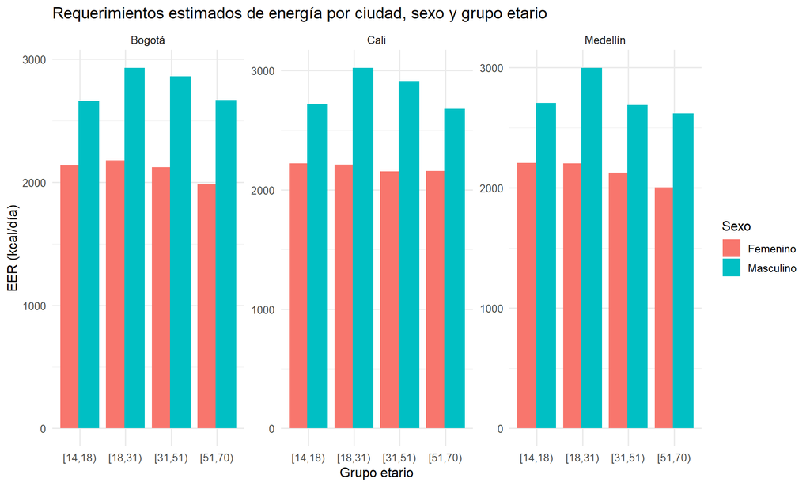

## 9.2 Peso promedio por ciudad, sexo y grupo etario

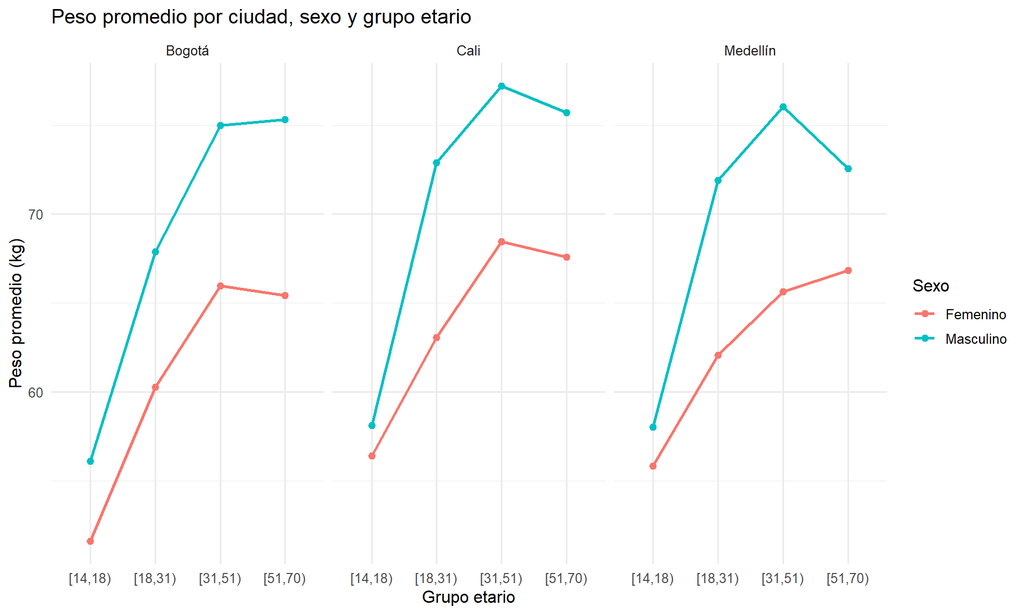

## 9.3 Talla promedio por ciudad, sexo y grupo etario

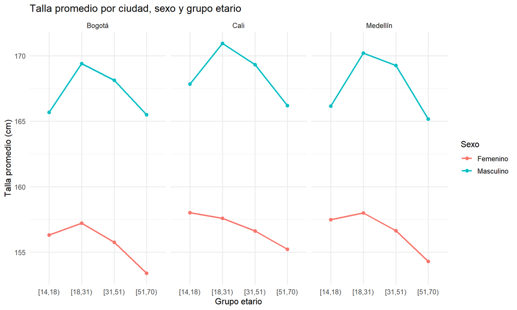

# 10 Comparación de resultados

En esta sección se sintetizan algunos indicadores descriptivos que facilitan una lectura comparada entre ciudades: el rango de EER estimado, así como los promedios de peso y talla.

Resumen descriptivo por ciudad

| dominio_geo | eer_min | eer_max | peso_promedio | talla_promedio |
| --- | --- | --- | --- | --- |
| Bogotá | 1983.4 | 2930.7 | 64.7 | 161.4 |
| Cali | 2156.0 | 3023.5 | 67.4 | 162.7 |
| Medellín | 2006.3 | 2998.8 | 66.1 | 162.2 |

# 11 Nota metodológica

1. La antropometría y la actividad física se estiman con **ENSIN 2015**.
2. La estructura poblacional proviene del **CNPV 2018**.
3. El EER se calcula con ecuaciones **NASEM 2023**.
4. La categoría de actividad física se aproxima así: **Ligera → Low active** y **Moderada → Active**.
5. El promedio final por ciudad puede presentarse de dos maneras: por grupos etarios o ponderado por la estructura poblacional observada en el censo.
6. La narrativa del documento sigue la lógica del HTML inicial, adaptándola de una ciudad a un análisis comparativo para **Cali, Bogotá y Medellín**.
7. La actividad física se estimó principalmente con **ENSIN 2015 para Cali, Bogotá y Medellín**. Para adultos mayores, se incorporó una exploración complementaria con **SABE 2015** a partir de variables de ejercicio y caminata frecuente (P407B_2, P409_11, P719, P720 y P721). Dado que en la versión trabajada de SABE no se incorporó una desagregación urbana equivalente para las tres ciudades, este complemento se interpreta como referencia agregada para población mayor.